# Week12 Tutorial - Recurrent Neural Network

1/4/2021

### 1. Dataset

Weather daily values were collected in Seattle from January 1, 1948, to December 12, 2017. #### Reference: https://www.kaggle.com/code/rtatman/beginner-s-intro-to-rnn-s-in-r/notebook

#### 1.2 Dependent variable

- Whether there was any precipitation

### 2. Recurrent neural network

A recurrent neural network predicts the value of the next time step based on the current time step and several previous successive time steps. Therefore, RNN has a better performance when dealing with sequential data since it considers previous experience.

### 3. Set up deep learning framework

In this experiment, we use Keras package. Keras package is built based on Tensorflow. Therefore, we install Tensorflow-2.5 first.

```r
# Import libraries
library(keras)
library(tidyverse)
library(caret)
```

### 4. Load and preview dataset

```r
# read in our data
weather_data <- read_csv("./seattleWeather_1948-2017.csv")
# check out the first few rows
head(weather_data)
```

| DATE | PRCP | TMAX | TMIN | RAIN |
| --- | --- | --- | --- | --- |
| 1948-01-01 | 0.47 | 51 | 42 | TRUE |
| 1948-01-02 | 0.59 | 45 | 36 | TRUE |
| 1948-01-03 | 0.42 | 45 | 35 | TRUE |
| 1948-01-04 | 0.31 | 45 | 34 | TRUE |
| 1948-01-05 | 0.17 | 45 | 32 | TRUE |
| 1948-01-06 | 0.44 | 48 | 39 | TRUE |

### 5. Hyperparameters

- max_len: the length of the sliding window.
- batch_size: the number of instances feeds into the model at each iteration.
- total_epochs: total number of epochs during the training process.

```r
max_len <- 6
batch_size <- 32
total_epochs <- 15

# Set a random seed for reproducability
set.seed(123)
```

### 6. Data preprocessing

#### 6.1 Label balance

```r
rain <- weather_data$RAIN
table(rain)
```

```
rain
FALSE  TRUE
14648 10900
```

#### 6.2 Generate training slices

Cut the sequential data in overlapping sample sequences of max_len characters.

```r
# Get a list of start indexes for our (overlapping) chunks
start_indexes <- seq(1, length(rain) - (max_len + 1), by = 3)

# Create an empty matrix to store our data in
weather_matrix <- matrix(nrow = length(start_indexes), ncol = max_len + 1)

# Fill our matrix with the overlapping slices of our dataset
for (i in 1:length(start_indexes)){
  weather_matrix[i,] <- rain[start_indexes[i]:(start_indexes[i] + max_len)]
}
```

#### 6.3 Data cleaning

1. Convert the input matrix to numeric because Keras expects a numeric matrix.
2. Remove any NULL value.

```r
# Convert matrix to numeric
weather_matrix <- weather_matrix * 1

# Remove NULL values
if(anyNA(weather_matrix)){
    weather_matrix <- na.omit(weather_matrix)
}
```

### 7. Split dataset

```r
# Generate dependent value matrix and independent value matrix
X <- weather_matrix[,-ncol(weather_matrix)]
y <- weather_matrix[,ncol(weather_matrix)]
```

### 8. Create training set and testing set

```r
training_index <- createDataPartition(y, p = .9,
                                  list = FALSE,
                                  times = 1)

# Training data
X_train <- array(X[training_index,], dim = c(length(training_index), max_len, 1))
y_train <- y[training_index]

# Testing data
X_test <- array(X[-training_index,], dim = c(length(y) - length(training_index), max_len, 1))
y_test <- y[-training_index]
```

### 9. LSTM model

#### 9.1 Create sequential model structure

```r
model <- keras_model_sequential()
# Define input layer
model %>% layer_dense(input_shape = dim(X_train)[2:3], units = max_len)
# Define LSTM layer
model %>% layer_lstm(units = 16, dropout = 0.25, recurrent_dropout = 0.25, return_sequences = FALSE)
# Define hidden dense layer
model %>% layer_dense(units = 8)
# Define output layer
model %>% layer_dense(units = 1, activation = 'sigmoid')
```

The output layer should have one unit since we are predicting whether a day will rain or not.

#### 9.2 Print model architecture

```r
summary(model)
```

```
Model: "sequential_7"
__________________________________________________________________________________________________
 Layer (type)                               Output Shape                           Param #
==================================================================================================
 dense_19 (Dense)                           (None, 6, 6)                           12

 lstm_5 (LSTM)                              (None, 16)                             1472

 dense_20 (Dense)                           (None, 8)                              136

 dense_21 (Dense)                           (None, 1)                              9

==================================================================================================
Total params: 1,629
Trainable params: 1,629
Non-trainable params: 0
__________________________________________________________________________________________________
```

#### 9.3 Define loss function, optimizer, and metrics

- Binary cross entropy reflects the probability of an instance falling into one of two groups.
- Optimizer controls the amount of loss being back-propagated to the network.
- Accuracy measures the performance of the model at each training step.

```r
model %>% compile(loss = 'binary_crossentropy',
                  optimizer = optimizer_adam(),
                  metrics = c('accuracy'))
```

### 10. Training process

```r
trained_model <- model %>% fit(
    x = X_train,
    y = y_train,
    batch_size = batch_size,
    epochs = total_epochs,
    validation_split = 0.1)
```

### 11. Evaluation

```r
trained_model
```

```
Final epoch (plot to see history):
        loss: 0.5838
    accuracy: 0.7119
    val_loss: 0.5564
val_accuracy: 0.7389
```

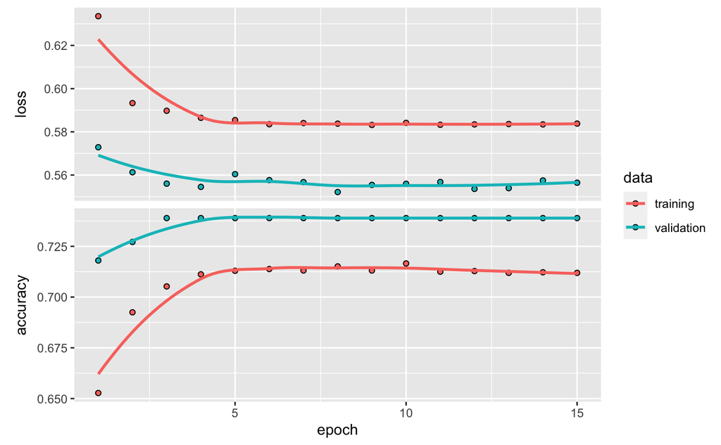

```r
plot(trained_model)
```

From this diagram, we can see that the model is well trained, and there is no overfitting.

### 12. Testing process

The confusion matrix compares the predictions to the ground-truth values.

```r
classes <- model %>% predict(X_test, batch_size = batch_size)
classes <- as.factor(ifelse(classes > 0.5, '1','0'))

# Confusion matrix
table(y_test, classes)
```

```
      classes
y_test   0   1
     0 355 132
     1 122 242
```

```r
model %>% evaluate(X_test, y_test, batch_size = batch_size)
```

```
     loss  accuracy
0.5912970 0.7015276
```

Our model predict with 70.2% accuracy on testing set.

```r
cat("Last Block!")
```